# Analysis

Compiled on Wed Mar 31 20:10:07 2021 by Corinna

## 0.2 Data Source

Personal Interviews

## 0.3 Reference

Panga Watch

## 0.4 Downloaded

September 30, 2019

Time range: 2019

## 0.5 Format

comma separated values

## 0.6 Standard opt-out model (Model I)

```r
standard_opt_out <- read_csv("int/standard_opt_out_fix.csv") %>%
  left_join(master_survey, by = "survey_id") %>%
  select(-noalt)
standard_clogit <- clogit(RES~ASC+sos+info+own.fisher+own.industry+own.gov + strata(survey_version), data=standard_opt_out) # run the clogit. ASC represents the alternative specific constant, or the opt out option.
summary(standard_clogit)
```

```
## Call:
## coxph(formula = Surv(rep(1, 633L), RES) ~ ASC + sos + info +
##     own.fisher + own.industry + own.gov + strata(survey_version),
##     data = standard_opt_out, method = "exact")
##
##   n= 633, number of events= 211
##
##                   coef exp(coef)  se(coef)      z Pr(>|z|)
## ASC          -0.886383  0.412144  0.442848 -2.002  0.04533 *
## sos           3.198063 24.485065  0.311713 10.260  < 2e-16 ***
## info          0.005698  1.005714  0.318873  0.018  0.98574
## own.fisher    1.091645  2.979170  0.412506  2.646  0.00814 **
## own.industry -1.271271  0.280475  0.495090 -2.568  0.01024 *
## own.gov       0.296550  1.345210  0.485331  0.611  0.54118
## ---
## Signif. codes:  0 '***' 0.001 '**' 0.01 '*' 0.05 '.' 0.1 ' ' 1
##
##              exp(coef) exp(-coef) lower .95 upper .95
## ASC             0.4121    2.42634    0.1730    0.9818
## sos            24.4851    0.04084   13.2914   45.1058
## info            1.0057    0.99432    0.5383    1.8789
## own.fisher      2.9792    0.33566    1.3273    6.6868
## own.industry    0.2805    3.56538    0.1063    0.7401
## own.gov         1.3452    0.74338    0.5196    3.4826
##
## Concordance= 0.81  (se = 0.02 )
## Likelihood ratio test= 209.1  on 6 df,   p=<2e-16
## Wald test            = 151.8  on 6 df,   p=<2e-16
## Score (logrank) test = 196  on 6 df,   p=<2e-16
```

```r
# CH: Dummy variable key

# SOS 0 = No
# SOS 1 = Yes

# Info 0 = Anonymous
# Info 1 = Non-anonymous

# own 1 = fisher
# own 2 = industry
# own 3 = Government
# Own 4 = Public
```

## 0.7 Pooled (Model II)

```r
pooled <- read_csv("int/pooled_data_fix.csv") %>%
  left_join(master_survey, by = "survey_id") %>%
  select(-noalt) %>%
  mutate(own = as.factor(own)) %>%
  mutate(info = as.factor(info)) %>%
  mutate(country = as.factor(country))
# CH: Reassign reference level of "own" to "4" which is public, and "info" to "1" which is non-anon:

pooled$own <- fct_relevel(pooled$own, "4")

pooled$info <- fct_relevel(pooled$info, "1")

# CH: Use levels(pooled$info) to check levels


pooled_clogit<-clogit(RES ~ sos + info + own + strata(STR), data=pooled)
summary(pooled_clogit)
```

```
## Call:
## coxph(formula = Surv(rep(1, 422L), RES) ~ sos + info + own +
##     strata(STR), data = pooled, method = "exact")
##
##   n= 422, number of events= 211
##
##          coef exp(coef) se(coef)      z Pr(>|z|)
## sos    2.4549   11.6448   0.3259  7.534 4.93e-14 ***
## info0  0.1317    1.1408   0.3458  0.381   0.7033
## own1   1.2044    3.3347   0.4280  2.814   0.0049 **
## own2  -0.3134    0.7310   0.5867 -0.534   0.5933
## own3   1.2269    3.4107   0.7010  1.750   0.0801 .
## ---
## Signif. codes:  0 '***' 0.001 '**' 0.01 '*' 0.05 '.' 0.1 ' ' 1
##
##       exp(coef) exp(-coef) lower .95 upper .95
## sos      11.645    0.08588    6.1485    22.055
## info0     1.141    0.87658    0.5792     2.247
## own1      3.335    0.29988    1.4412     7.716
## own2      0.731    1.36803    0.2315     2.308
## own3      3.411    0.29319    0.8633    13.474
##
## Concordance= 0.877  (se = 0.032 )
## Likelihood ratio test= 144.3  on 5 df,   p=<2e-16
## Wald test            = 73.68  on 5 df,   p=2e-14
## Score (logrank) test = 117.8  on 5 df,   p=<2e-16
```

```r
pooled_clogit2<-clogit(RES ~ sos + info +  own.fisher + own.industry  + own.gov + strata(STR), data=pooled)
summary(pooled_clogit2) # CH: added 2 at the end, because this version of the model is used for the preference weights figure. Gage had this as the one we used and commented out the one I am now using. The results were the same though....
```

```
## Call:
## coxph(formula = Surv(rep(1, 422L), RES) ~ sos + info + own.fisher +
##     own.industry + own.gov + strata(STR), data = pooled, method = "exact")
##
##   n= 422, number of events= 211
##
##                 coef exp(coef) se(coef)      z Pr(>|z|)
## sos           2.4549   11.6448   0.3259  7.534 4.93e-14 ***
## info0         0.1317    1.1408   0.3458  0.381   0.7033
## own.fisher    1.2044    3.3347   0.4280  2.814   0.0049 **
## own.industry -0.3134    0.7310   0.5867 -0.534   0.5933
## own.gov       1.2269    3.4107   0.7010  1.750   0.0801 .
## ---
## Signif. codes:  0 '***' 0.001 '**' 0.01 '*' 0.05 '.' 0.1 ' ' 1
##
##              exp(coef) exp(-coef) lower .95 upper .95
## sos             11.645    0.08588    6.1485    22.055
## info0            1.141    0.87658    0.5792     2.247
## own.fisher       3.335    0.29988    1.4412     7.716
## own.industry     0.731    1.36803    0.2315     2.308
## own.gov          3.411    0.29319    0.8633    13.474
##
## Concordance= 0.877  (se = 0.032 )
## Likelihood ratio test= 144.3  on 5 df,   p=<2e-16
## Wald test            = 73.68  on 5 df,   p=2e-14
## Score (logrank) test = 117.8  on 5 df,   p=<2e-16
```

```r
pooled_clogit3 <- clogit(RES ~ sos + info + own + country + strata(STR), data = pooled)
summary(pooled_clogit3)
```

```
## Call:
## coxph(formula = Surv(rep(1, 422L), RES) ~ sos + info + own +
##     country + strata(STR), data = pooled, method = "exact")
##
##   n= 422, number of events= 211
##
##               coef exp(coef) se(coef)      z Pr(>|z|)
## sos         2.4549   11.6448   0.3259  7.534 4.93e-14 ***
## info0       0.1317    1.1408   0.3458  0.381   0.7033
## own1        1.2044    3.3347   0.4280  2.814   0.0049 **
## own2       -0.3134    0.7310   0.5867 -0.534   0.5933
## own3        1.2269    3.4107   0.7010  1.750   0.0801 .
## countryMEX      NA        NA   0.0000     NA       NA
## ---
## Signif. codes:  0 '***' 0.001 '**' 0.01 '*' 0.05 '.' 0.1 ' ' 1
##
##            exp(coef) exp(-coef) lower .95 upper .95
## sos           11.645    0.08588    6.1485    22.055
## info0          1.141    0.87658    0.5792     2.247
## own1           3.335    0.29988    1.4412     7.716
## own2           0.731    1.36803    0.2315     2.308
## own3           3.411    0.29319    0.8633    13.474
## countryMEX        NA         NA        NA        NA
##
## Concordance= 0.877  (se = 0.032 )
## Likelihood ratio test= 144.3  on 5 df,   p=<2e-16
## Wald test            = 73.68  on 5 df,   p=2e-14
## Score (logrank) test = 117.8  on 5 df,   p=<2e-16
```

```r
# CH: pooled_clogit is used as "model 1" in our paper to showcase conditional logit results
```

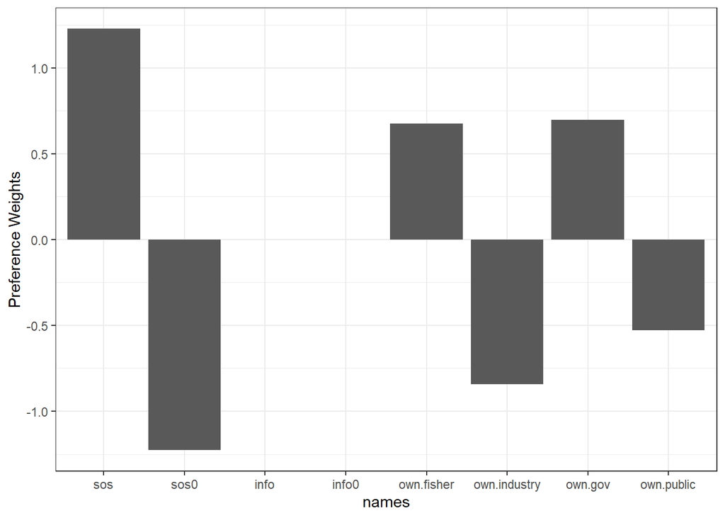

```r
# CH: This is not working right after I changed the reference level for info in the models above...

# make the graphs for actual preference weights

sos_coef <- pooled_clogit2$coefficients[1]
info_coef <- pooled_clogit2$coefficients[2]
own_1_coef <- pooled_clogit2$coefficients[3]
own_2_coef <- pooled_clogit2$coefficients[4]
own_3_coef <- pooled_clogit2$coefficients[5]

pooled_clogit_coefs <- data.frame(names = names(pooled_clogit2$coefficients), clogit_coef = pooled_clogit2$coefficients)

avg_own <- (own_1_coef + own_2_coef + own_3_coef)/4
avg_info <- (info_coef)/2
avg_sos <- sos_coef/2

sos_actual <- pooled_clogit_coefs %>%
  filter(names == "sos") %>%
  mutate(actual = clogit_coef - avg_sos)

sos0_actual <- data.frame(names = "sos0", 0, actual = -sum(sos_actual$actual)) %>%
  rename("clogit_coef" = "X0")

sos_actual_final <- rbind(sos_actual, sos0_actual)

sos_actual_final <- rbind(sos_actual, sos0_actual)

info_actual <- pooled_clogit_coefs %>%
  filter(names == "info") %>%
  mutate(actual = clogit_coef - avg_info)

info0_actual <- data.frame(names = "info0", 0, actual = -sum(info_actual$actual)) %>%
  rename("clogit_coef" = "X0")

info_actual_final <- rbind(info_actual, info0_actual)

own_actual <- pooled_clogit_coefs %>%
  filter(str_detect(names, 'own') ) %>%
  mutate(actual = clogit_coef - avg_own)

own4_actual <- data.frame(names = "own.public",  0, actual =-sum(own_actual$actual)) %>%
  rename("clogit_coef" = "X0")

own_actual_final <- rbind(own_actual, own4_actual)

all_actual <- rbind(sos_actual_final, info_actual_final, own_actual_final) %>%
  select(-clogit_coef)
# write.csv(all_actual, "output/pooled_clogit_actual_coefs.csv", row.names = FALSE)

# all_actual <- read_csv("output/pooled_clogit_actual_coefs.csv")

# previous two lines commented out b/c I do not have a output folder to write it to, this is a remnant from Gage's work

positions <- c("sos", "sos0", "info", "info0", "own.fisher", "own.industry", "own.gov", "own.public")

all_actual %>%
  ggplot(aes(x= names, y= actual)) +
  geom_col() +
  theme_bw() +
  scale_x_discrete(limits = positions) +
  scale_y_continuous(breaks = seq(-1.3, 1.3, 0.1)) %>%
  labs(y = "Preference Weights")
```

## 0.8 Unforced Responses (Model III)

```r
unforced <- read_csv("int/unforced_data_fix.csv") %>%
  left_join(master_survey, by = "survey_id") %>%
  select(-noalt)
unforced_clogit<-clogit(RES~sos+info+own.fisher+own.industry+own.gov+strata(STR), data=unforced)
unforced_clogit
```

```
## Call:
## clogit(RES ~ sos + info + own.fisher + own.industry + own.gov +
##     strata(STR), data = unforced)
##
##                 coef exp(coef) se(coef)      z        p
## sos           3.2019   24.5797   0.4834  6.624 3.49e-11
## info          0.1345    1.1439   0.5147  0.261   0.7939
## own.fisher    1.0870    2.9653   0.5256  2.068   0.0386
## own.industry -0.9746    0.3774   0.7779 -1.253   0.2103
## own.gov       0.9339    2.5444   0.9579  0.975   0.3296
##
## Likelihood ratio test=148.5  on 5 df, p=< 2.2e-16
## n= 338, number of events= 169
```

## 0.9 Forced Responses (Model IV)

```r
forced <- read_csv("int/forced_data_fix.csv") %>%
  left_join(master_survey, by = "survey_id") %>%
  select(-noalt)
forced_clogit<-clogit(RES~sos+info+own.fisher+own.industry+own.gov+own.public+strata(STR), data=forced)
forced_clogit
```

```
## Call:
## clogit(RES ~ sos + info + own.fisher + own.industry + own.gov +
##     own.public + strata(STR), data = forced)
##
##                 coef exp(coef) se(coef)      z      p
## sos           1.1429    3.1360   0.5224  2.188 0.0287
## info         -0.6659    0.5138   0.5497 -1.211 0.2257
## own.fisher    1.4334    4.1929   0.8115  1.766 0.0773
## own.industry  0.7665    2.1522   1.1210  0.684 0.4941
## own.gov       1.9929    7.3365   1.2188  1.635 0.1020
## own.public        NA        NA   0.0000     NA     NA
##
## Likelihood ratio test=13.73  on 5 df, p=0.01742
## n= 84, number of events= 42
```

**Likelihood Ratio Test Taken from Penn et al.**

```r
#K = 5
#M = 2

pooled_log <- logLik(pooled_clogit) #-74.11078 (df=5)
unforced_log <- logLik(unforced_clogit) #-42.90397 (df=5)
forced_log <- logLik(forced_clogit) #-22.24721 (df=5)

-2*(logLik(pooled_clogit) - (logLik(unforced_clogit) + logLik(forced_clogit)))
```

```
## 'log Lik.' 17.91918 (df=5)
```

```r
-2*(pooled_log- (unforced_log + forced_log))
```

```
## 'log Lik.' 17.91918 (df=5)
```

```r
-2*(74.11078 - (42.90397 + 22.24721)) #17.9192
```

```
## [1] -17.9192
```

```r
# if this then 17.9192 < 20.52 which means that we do not reject the null that there is no difference between the forced and unforced........... need to write this up formally
```

Methods Log Lik Test: We can test the effect of forced choice versus unforced choice using a likelihood ratio test for equality. The test statistic is:

$$-2*(LL_{r} - \sum LL{u})$$
Which is chi-squared distributed with K(M-1) degrees of freedom, where K is the number of restrictions (5), M is the number of treatments (2). The null hypothesis of the test is that the parameters are not significantly different between treatments. This means that if we do not reject the null, we can use the standard opt out method without worry of respondent bias. If the test statistic exceeds the critical value, found in the chi square table, then evidence suggests that the treatments sufficiently contribute to explaining the model and reject the null hypothesis of no difference between the forced and unforced datasets.

## 0.10 Stargazer table and coefficient plot of pooled model

```r
# Table
final_table <- stargazer(pooled_clogit, pooled_clogit2, pooled_clogit3, type = "html")
```

|  | *Dependent variable:* |  |  |
| --- | --- | --- | --- |
|  | RES |  |  |
|  | (1) | (2) | (3) |
| sos | 2.455*** | 2.455*** | 2.455*** |
|  | (0.326) | (0.326) | (0.326) |
| info0 | 0.132 | 0.132 | 0.132 |
|  | (0.346) | (0.346) | (0.346) |
| own1 | 1.204*** |  | 1.204*** |
|  | (0.428) |  | (0.428) |
| own2 | -0.313 |  | -0.313 |
|  | (0.587) |  | (0.587) |
| own3 | 1.227* |  | 1.227* |
|  | (0.701) |  | (0.701) |
| own.fisher |  | 1.204*** |  |
|  |  | (0.428) |  |
| own.industry |  | -0.313 |  |
|  |  | (0.587) |  |
| own.gov |  | 1.227* |  |
|  |  | (0.701) |  |
| countryMEX |  |  |  |
|  |  |  | (0.000) |
| Observations | 422 | 422 | 422 |
| R<sup>2</sup> | 0.290 | 0.290 | 0.290 |
| Max. Possible R<sup>2</sup> | 0.500 | 0.500 | 0.500 |
| Log Likelihood | -74.111 | -74.111 | -74.111 |
| Wald Test (df = 5) | 73.680*** | 73.680*** | 73.680*** |
| LR Test (df = 5) | 144.287*** | 144.287*** | 144.287*** |
| Score (Logrank) Test (df = 5) | 117.835*** | 117.835*** | 117.835*** |
| *Note:* | p<0.1; p<0.05; p<0.01 |  |  |

[figure not shown]

```r
# Plot
final_plot <- coefplot(pooled_clogit, color = "black") +
  scale_y_discrete(name="Feature",
                   labels=c("SOS Feature","Non-Private Information","Fisher Owned Data","Industry Owned Data","Government Owned Data")) +
  theme_classic()
final_plot
```